# Ford GoBike System Dataset Analysis

## by Reem Helal

## Investigation Overview

> In this presentation we focus on the main features of Ford GoBike System Dataset in 2017.

## Ford GoBike System Dataset Overview

> Ford GoBike dataset includes information about individual rides made in a bike-sharing system covering the greater San Francisco Bay area. The dataset of year 2017 is consists of 519,700 records for the following variables :

> We collect the dataset from : https://www.lyft.com/bikes/bay-wheels/system-data.

### • What is the structure of GoBike dataset?

The dataset composed of 519,700 records for :

- Trip Duration (seconds).
- Start Time and Date.
- End Time and Date.
- Start Station ID.
- Start Station Name.
- Start Station Latitude.
- Start Station Longitude.
- End Station ID.
- End Station Name.
- End Station Latitude.
- End Station Longitude.
- Bike ID.
- User Type (Subscriber or Customer – “Subscriber” = Member or “Customer” = Casual).

### • What are the main features of interest in GoBike dataset?

The keys of interests are :

1. The duration of the bike trip.
2. The seasons of bike trips.
3. The stations where the bike trip starts and ends.
4. The time details of the bike trip in 2017 (month, day and hour).
5. Bike riders types.

### • What features in GoBike dataset will help to support the analysis process?

The supportive dataset features are :

1. Trip Duration (seconds).
2. Start Time and Date.
3. End Time and Date.
4. Start Station Name.
5. End Station Name.
6. User Type (Subscriber or Customer – “Subscriber” = Member or “Customer” = Casual).

## • Bike Trip Seasons in 2017

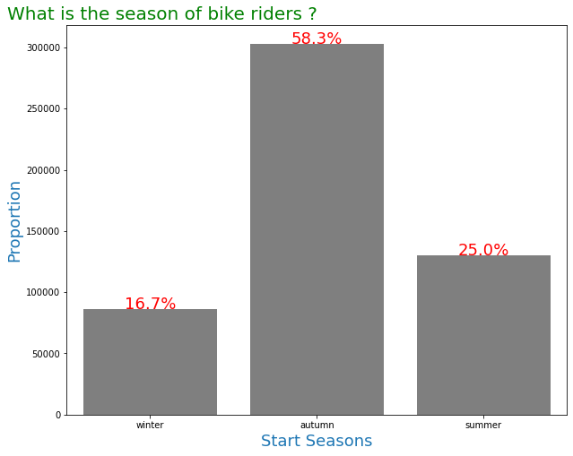

```python
# create the plot for the proportion of each season across 2017 in Start_Season.
fig, ax = plt.subplots(figsize=(10,8))
fntsz = 18
fntclr = sb.color_palette()[0]
bs_color = sb.color_palette()[7]

sb.countplot(data = bike_df, x = 'Start_Seasons', color = bs_color, ax = ax)

# add annotations
n_points = bike_df.shape[0]
seasons_no = bike_df['Start_Seasons'].value_counts()
locs, labels = plt.xticks()

for loc, label in zip(locs, labels):
    count = seasons_no[label.get_text()]
    pct_string = '{:0.1f}%'.format(100 * count/n_points)
    plt.text(loc, count-8, pct_string, ha = 'center', color = 'r', fontsize = 18)

plt.xlabel('Start Seasons', fontsize = fntsz, color = fntclr)
plt.ylabel('Proportion', fontsize = fntsz, color = fntclr)
plt.title('What is the season of bike riders ?', ha = 'right', fontsize = 20, color = 'g');
```

## • Bike Trips User Types

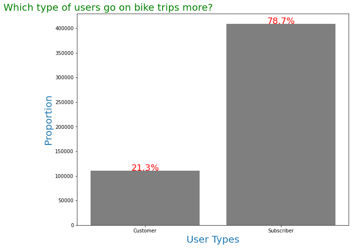

```python
# create the plot for the proportion of each bike riders types across 2017.
fig, ax = plt.subplots(figsize=(10,8))
fntsz = 18
fntclr = sb.color_palette()[0]
bs_color = sb.color_palette()[7]
sb.countplot(data = bike_df, x = 'user_type', color = bs_color, ax = ax)

n_points = bike_df.shape[0]
users_no = bike_df['user_type'].value_counts()
locs, labels = plt.xticks()

for loc, label in zip(locs, labels):

    count = users_no[label.get_text()]
    pct_string = '{:0.1f}%'.format(100*count/n_points)
    plt.text(loc, count-8, pct_string, ha = 'center', color = 'r', fontsize = 18)

plt.xlabel('User Types', fontsize = 20, color = fntclr)
plt.ylabel('Proportion', fontsize = 20, color = fntclr)
plt.title('Which type of users go on bike trips more?', ha = 'right', fontsize = 20, color = 'g');
```

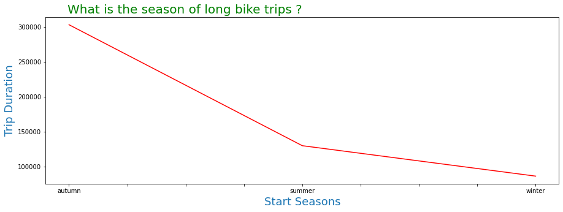

```python
#Visualize the duration_sec vs seasons.
duration_df.count().plot(title = 'Trips duration across seasons', kind = 'line', figsize = (15,5), color = 'r')
plt.xlabel('Start Seasons', fontsize = fntsz, color = fntclr)
plt.ylabel('Trip Duration', fontsize = fntsz, color = fntclr)
plt.title('What is the season of long bike trips ?', ha = 'right', fontsize = 20, color = 'g');
```

## Days of Bike Trips

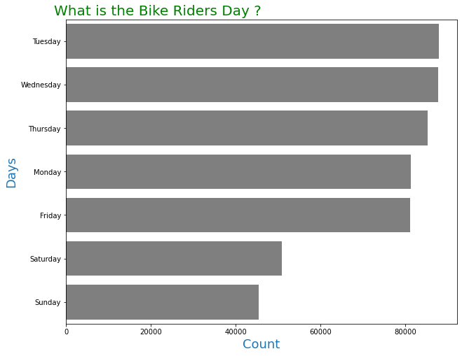

```python
#Plot the days of bike trips in start_time.
fig, ax = plt.subplots(figsize=(10,8))
bs_color = sb.color_palette()[7]
days_ordr = bike_df['start_time_day'].value_counts().index
sb.countplot(data = bike_df, y = 'start_time_day', color = bs_color, order = days_ordr, ax = ax);
plt.title('What is the Bike Riders Day ?', ha = 'right' ,fontsize = 20, color = 'g')
plt.xlabel('Count', fontsize = fntsz, color = fntclr)
plt.ylabel('Days', fontsize = fntsz, color = fntclr);
```

## Hours of Bike Riders

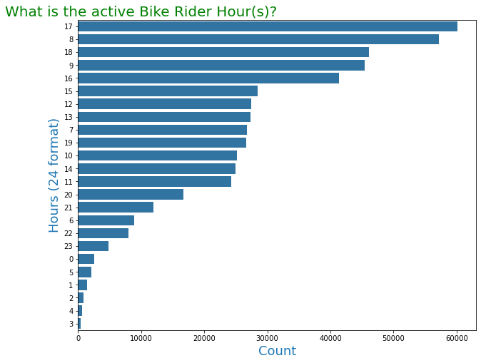

```python
#Plot the hours of bike trips in start_time.
fig, ax = plt.subplots(figsize=(10,8))
bs_color = sb.color_palette()[0]
days_ordr = bike_df['start_time_hour'].value_counts().index
sb.countplot(data = bike_df, y = 'start_time_hour', color = bs_color, order = days_ordr, ax = ax);

plt.title('What is the active Bike Rider Hour(s)?', ha = 'right' ,fontsize = 20, color = 'g')
plt.xlabel('Count', fontsize = fntsz, color = fntclr)
plt.ylabel('Hours (24 format)', fontsize = fntsz, color = fntclr);
```

## Month of Bike Riders

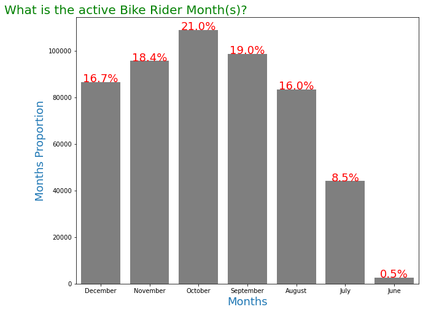

```python
# create the plot for the proportion of each start_time_month across 2017.
fig, ax = plt.subplots(figsize=(10,8))
bs_color = sb.color_palette()[7]
sb.countplot(data = bike_df, x = 'start_time_month', color = bs_color, ax = ax)

n_points = bike_df.shape[0]
users_no = bike_df['start_time_month'].value_counts()
locs, labels = plt.xticks()

for loc, label in zip(locs, labels):

    count = users_no[label.get_text()]
    pct_string = '{:0.1f}%'.format(100*count/n_points)
    plt.text(loc, count-8, pct_string, ha = 'center', color = 'r', fontsize = 18)

plt.title('What is the active Bike Rider Month(s)?', ha = 'right' ,fontsize = 20, color = 'g')
plt.xlabel('Months', fontsize = fntsz, color = fntclr)
plt.ylabel('Months Proportion', fontsize = fntsz, color = fntclr);
```

## Top 10 Bike Riding Starting Stations

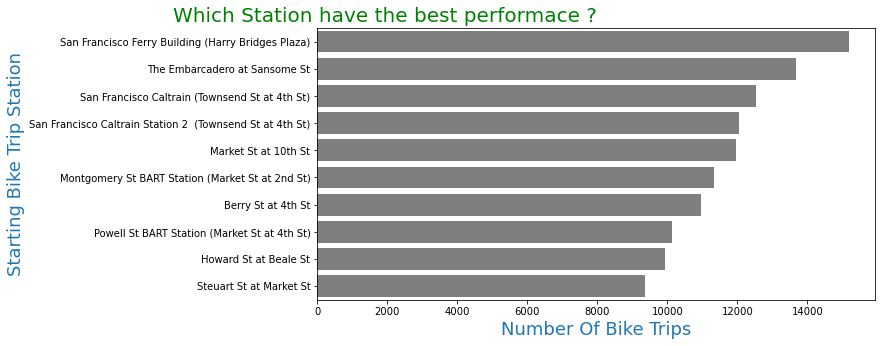

```python
#Plot the top 10 starting stations
fig, ax = plt.subplots(figsize=(10,5))
bs_color = sb.color_palette()[7]
station_ordr = bike_df['start_station_name'].value_counts().index[0:10]
sb.countplot(data = bike_df, y = 'start_station_name', color = bs_color, order = station_ordr, ax = ax);


plt.title('Which Station have the best performace ?', ha = 'right' ,fontsize = 20, color = 'g')
plt.xlabel('Number Of Bike Trips', fontsize = fntsz, color = fntclr)
plt.ylabel('Starting Bike Trip Station', fontsize = fntsz, color = fntclr);
```

## Top 10 Bike Riding Ending Stations

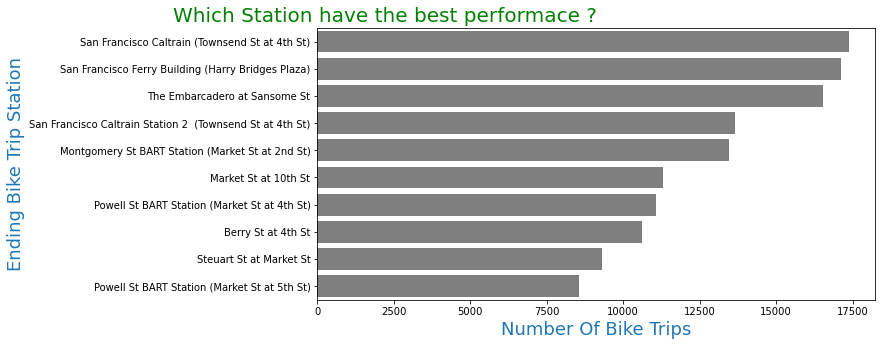

```python
#Plot the top 10 ending stations
fig, ax = plt.subplots(figsize=(10,5))
bs_color = sb.color_palette()[7]
station_ordr = bike_df['end_station_name'].value_counts().index[0:10]
sb.countplot(data = bike_df, y = 'end_station_name', color = bs_color, order = station_ordr, ax = ax);

plt.title('Which Station have the best performace ?', ha = 'right' ,fontsize = 20, color = 'g')
plt.xlabel('Number Of Bike Trips', fontsize = fntsz, color = fntclr)
plt.ylabel('Ending Bike Trip Station', fontsize = fntsz, color = fntclr);
```

## User Types V.S. Seasons

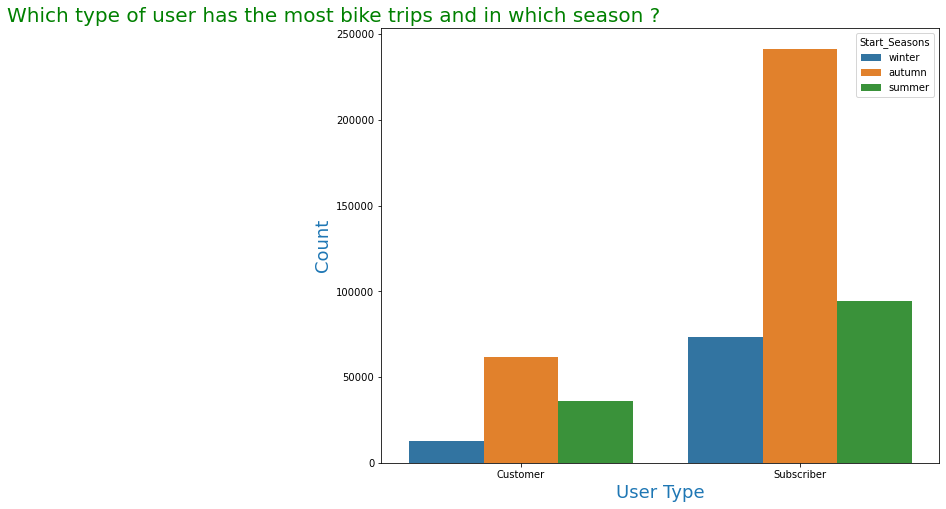

```python
fig, ax = plt.subplots(figsize=(10,8))
sb.countplot(data = bike_df, x = 'user_type' , hue = 'Start_Seasons', ax = ax);

plt.title('Which type of user has the most bike trips and in which season ?', ha = 'right' ,fontsize = 20, color = 'g')
plt.xlabel('User Type', fontsize = fntsz, color = fntclr)
plt.ylabel('Count', fontsize = fntsz, color = fntclr);
```

> $Subsribers$ with $241,536$ bike riders and $Customer$ with $61,571$ bike riders are the most in Autumn season in 2017.

## Trip Duration V.S Months

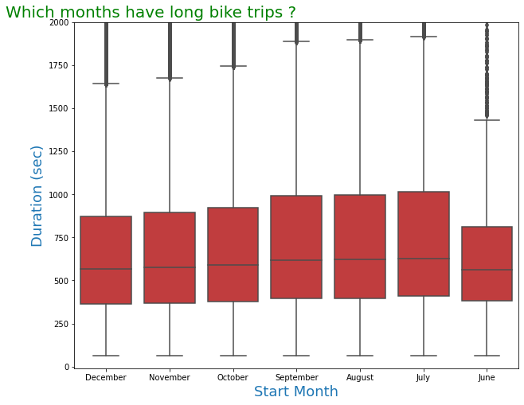

```python
plt.figure(figsize = [10, 8])
bs_color = sb.color_palette()[3]
sb.boxplot(data = bike_df, x = 'start_time_month', y = 'duration_sec', color = bs_color)
plt.ylim([-10, 2000])

plt.title('Which months have long bike trips ?', ha = 'right' ,fontsize = 20, color = 'g')
plt.xlabel('Start Month', fontsize = fntsz, color = fntclr)
plt.ylabel('Duration (sec)', fontsize = fntsz, color = fntclr);
plt.show()
```

## Active Days per Seaons

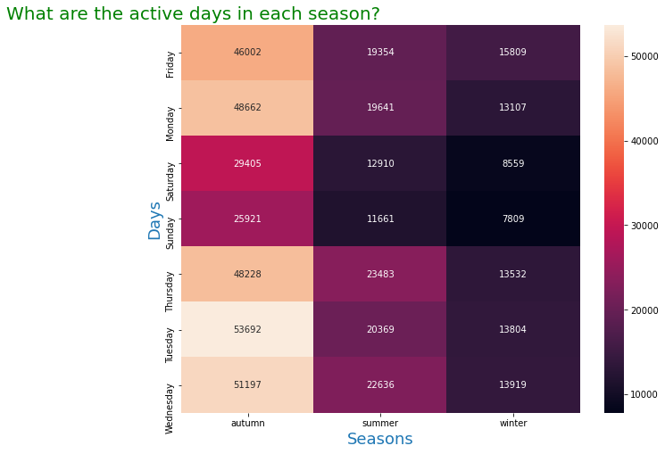

```python
fig, ax = plt.subplots(figsize=(10,8))
day_counts = bike_df.groupby(['start_time_day', 'Start_Seasons']).size()
day_counts = day_counts.reset_index(name = 'count')
day_counts = day_counts.pivot(index = 'start_time_day', columns = 'Start_Seasons', values = 'count')
sb.heatmap(day_counts, annot = True, fmt = 'd', ax = ax);

plt.title('What are the active days in each season?', ha = 'right' ,fontsize = 20, color = 'g')
plt.xlabel('Seasons', fontsize = fntsz, color = fntclr)
plt.ylabel('Days', fontsize = fntsz, color = fntclr);
plt.show()
```

## Active Hours per Day

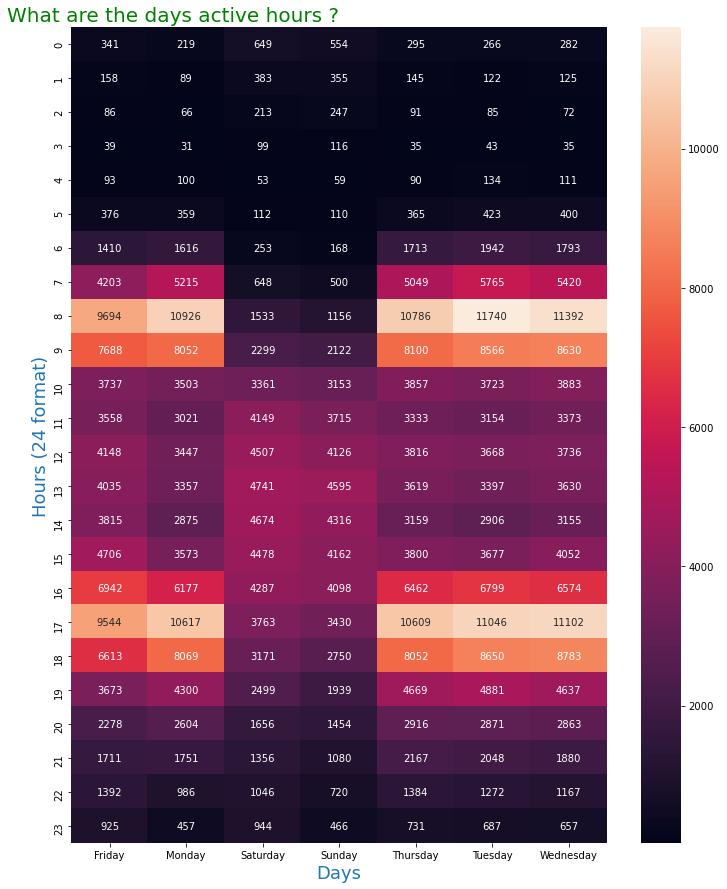

```python
day_counts = bike_df.groupby(['start_time_day', 'start_time_hour']).size()
day_counts = day_counts.reset_index(name = 'count')
day_counts = day_counts.pivot(index = 'start_time_hour', columns = 'start_time_day', values = 'count')
fig, ax = plt.subplots(figsize=(12,15))
sb.heatmap(day_counts, annot = True, fmt = 'd', ax = ax);

plt.title('What are the days active hours ?', ha = 'right' ,fontsize = 20, color = 'g')
plt.xlabel('Days', fontsize = fntsz, color = fntclr)
plt.ylabel('Hours (24 format)', fontsize = fntsz, color = fntclr);
plt.show()
```

## User Types V.S Top 10 Starting Stations

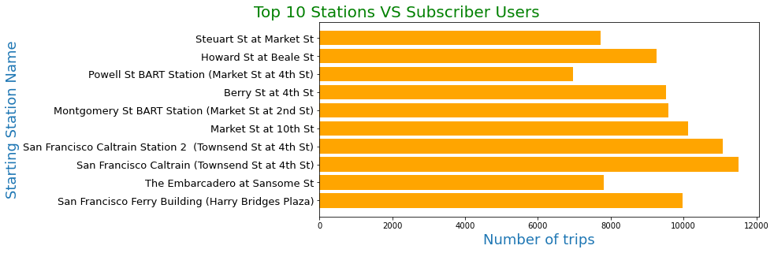

```python
x_subsriber = subsriber_df.index[0:10]
y_subsriber = subsriber_df.values[0:10]

x_customer = customer_df.index[0:10]
y_customer = customer_df.values[0:10]

#Plot the top 10 starting stations VS Subscribers.
plt.figure(figsize = [10, 10])

plt.subplot(2,1,1)
plt.barh(x, subsriber_df[x],color ='orange')
plt.yticks(fontsize = 13)
plt.title('Top 10 Stations VS Subscriber Users', ha = 'right', fontsize = 20, color = 'g')
plt.xlabel('Number of trips', fontsize = fntsz, color = fntclr)
plt.ylabel('Starting Station Name', fontsize = fntsz, color = fntclr);
```

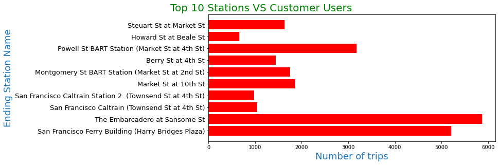

```python
#Plot the top 10 starting stations VS Customers.
plt.figure(figsize = [10, 10])

plt.subplot(2,1,1)
plt.barh(x, customer_df[x], color = 'r')
plt.yticks(fontsize = 13)
plt.title('Top 10 Stations VS Customer Users', ha = 'right', fontsize = 20, color = 'g')
plt.xlabel('Number of trips', fontsize = fntsz, color = fntclr)
plt.ylabel('Ending Station Name', fontsize = fntsz, color = fntclr);
```

## Relationship between Features

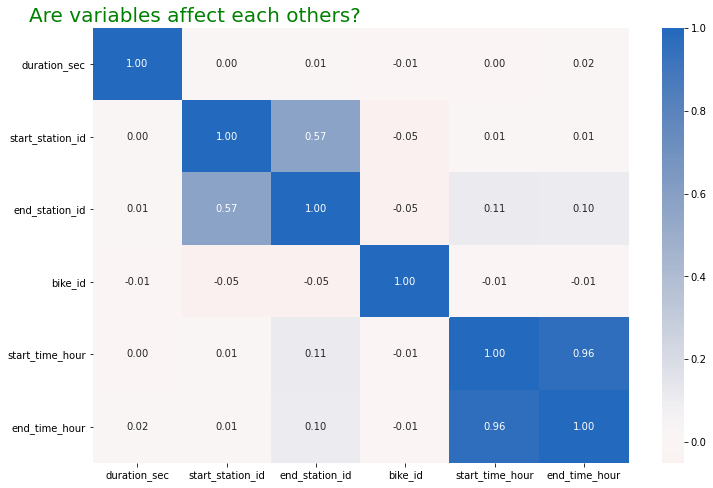

```python
fig, ax = plt.subplots(figsize=(12,8))
sb.heatmap(bike_df.corr(), annot = True, fmt = '.2f', cmap = 'vlag_r', center = 0, ax = ax);

plt.title('Are variables affect each others?', ha = 'right', fontsize = 20, color = 'g');
```

## Trips Duration and Season with the User Types

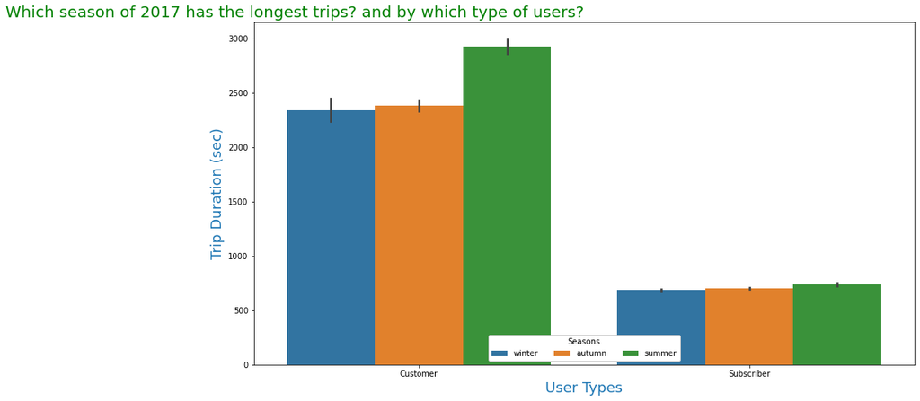

```python
fig, ax = plt.subplots(figsize=(15,8))
axis = sb.barplot(data = bike_df, x = 'user_type', y = 'duration_sec', hue = 'Start_Seasons')
axis.legend(loc = 8, ncol = 3, framealpha = 1, title = 'Seasons');

plt.title('Which season of 2017 has the longest trips? and by which type of users?', ha = 'right', fontsize = 20, color = 'g')
plt.xlabel('User Types', fontsize = fntsz, color = fntclr)
plt.ylabel('Trip Duration (sec)', fontsize = fntsz, color = fntclr);
```

## Days and Hours with the Season in 2017

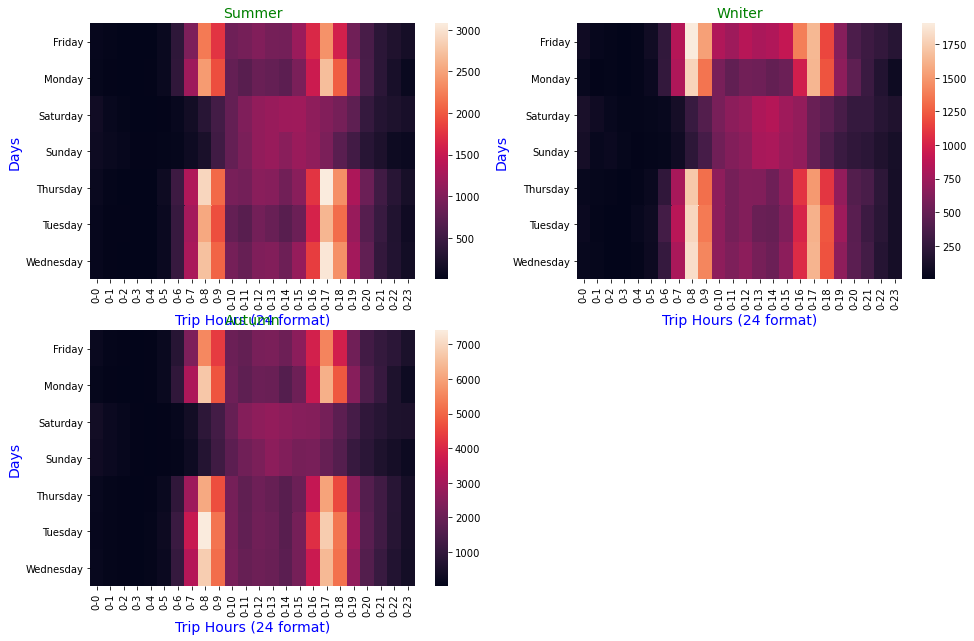

```python
#Plot the heat map fpr each season.
plt.figure(figsize = [16, 16])
fontSize = 14
fontColor = 'blue'

plt.subplot(3,2,1)
sb.heatmap(summer_df.pivot('start_time_day','start_time_hour'));
plt.title('Summer' , fontsize = fontSize, color = 'g')
plt.ylabel('Days', fontsize = fontSize, color = fontColor)
plt.xlabel('Trip Hours (24 format)', fontsize = fontSize, color = fontColor);

plt.subplot(3,2,2)
sb.heatmap(winter_df.pivot('start_time_day','start_time_hour'));
plt.title('Wniter', fontsize = fontSize, color = 'g')
plt.ylabel('Days', fontsize = fontSize, color = fontColor)
plt.xlabel('Trip Hours (24 format)', fontsize = fontSize, color = fontColor);

plt.subplot(3,2,3)
sb.heatmap(autumn_df.pivot('start_time_day','start_time_hour'));
plt.title('Autumn', fontsize = fontSize, color = 'g')
plt.ylabel('Days', fontsize = fontSize, color = fontColor)
plt.xlabel('Trip Hours (24 format)', fontsize = fontSize, color = fontColor);
```

### Conclusion

> As a conclusion, we can say that Autumn was the most active bike riding season where Summer comes to the fist place when we put the duration of the trip in our consideration. The thing which is really strange that there is NO bike riders in Spring, and I think that is because there is no data for Spring season in this dataset. Subscriber users are the most bike riders in all season where Customer users comes to the first place when it comes to consider the duration of the trip. Moreover 8 Am and 5 PM are the most biking trips across the working days for all seasons.

```python
!jupyter nbconvert GoBike_Explanation.ipynb --to slides --template output_toggle
```

```
[NbConvertApp] Converting notebook GoBike_Explanation.ipynb to slides
[NbConvertApp] Writing 1026010 bytes to GoBike_Explanation.slides.html
```